# Atividade 2 – Geração de Números Aleatórios: Variáveis Aleatórias Discretas & Misturas

Author

Milena Paz Freitas

# Questão 1

**Enunciado:** Construa um gerador da variável aleatória X, com função de probabilidade $f_X(1)=\frac{1}{3}$ e $f_X(2)=\frac{2}{3}$.

1. Use seu gerador e estime a proporção de valores iguais a um, para n = 100.
2. Repita (a) para n = 1.000.
3. Repita (a) para n = 10.000.

```r
#X é semelhante a uma Bernoulli(2/3), que ao invés de assumir valores 0 ou 1, assume 1 ou 2.
#ou seja, podemos fazer o seguinte:
p <- 2/3

rBern<- function(n,p){
  U <- runif(n)
  return(as.numeric(U<=p))
}
#A), B) e C)
for(n in c(100,1E3,1E4)){
  #gera a bernoulli e soma 1
  X <- rBern(n,p) + 1
  #estimativa da proporção de x=1
  print(paste("Proporção de x=1 para n =", n))
  print(mean(X==1))
}
```

```
[1] "Proporção de x=1 para n = 100"
[1] 0.33
[1] "Proporção de x=1 para n = 1000"
[1] 0.324
[1] "Proporção de x=1 para n = 10000"
[1] 0.3313
```

# Questão 3

**Enunciado:** Um baralho de 100 cartas, numeradas de 1 a 100, é embaralhado. Vira-se uma carta por vez. Digamos que um “ponto” ocorra sempre que a carta i for a i-ésima carta virada, i = 1, 2, …, 100. Escreva um código para simulação desse jogo e estime a esperança e a variância do número total de “pontos”. Execute o programa. Determine as respostas exatas e compare-as com suas estimativas.

Seja X o número total de pontos, podemos modelar esse jogo como uma variável aleatória binomial com 1/100 de probabilidade de sucesso. Assim, temos que:

$$\begin{aligned}
& \text E(X)= 100\frac{1}{100}=1
\\
& \text{Var}(X) = 100\frac{1}{100}\frac{99}{100}=0,99
\end{aligned}$$

```r
#podemos usar a soma de bernoullis para simular X
jogo <- function(){
  return(sum(rBern(100,0.01))) #usa a funcao geradora da questao 1
}

X<- replicate(1E3, jogo())

mean(X)
```

```
[1] 0.902
```

```r
var(X)
```

```
[1] 0.9633594
```

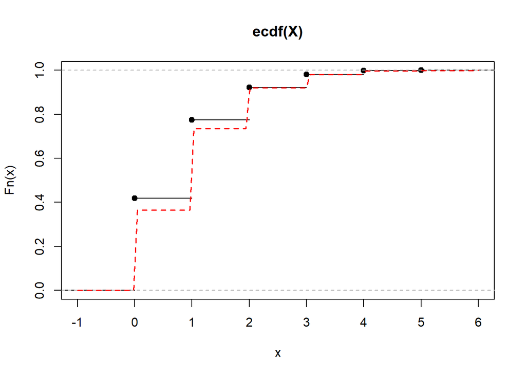

```r
plot(ecdf(X))
curve(pbinom(x,100,0.01),add=T,col="red",lwd=1.5,lty=2)
```

# Questão 5

**Enunciado:** Suponha que a variável aleatória X possa tomar qualquer um dos valores 1, 2, …, 10, com probabilidades 0,06; 0,06; 0,06; 0,06; 0,06; 0,15; 0,13; 0,14; 0,15; 0,13. Use a abordagem por composição (composite approach) para construir um algoritmo que gere os valores de X.

```r
#metodo da composicao
probs<- c(0.06,0.06,0.06,0.06,0.06,0.15,0.13,0.14,0.15,0.13)

geraComp <- function(n,probs){
  intervalos <- cumsum(c(0,probs))
  U<- runif(n)
  X<- numeric(n)
  for(i in seq_along(probs)){
    caso <- U <= intervalos[i+1] & U> intervalos[i]
    X[caso] <- i
  }
  return(X)
}
X<- geraComp(1E3,probs)
rbind(p.Gerados=table(X)/1E3,p.Teoricos= probs)
```

```
               1     2     3     4     5     6     7     8     9    10
p.Gerados  0.054 0.061 0.074 0.062 0.056 0.151 0.133 0.148 0.135 0.126
p.Teoricos 0.060 0.060 0.060 0.060 0.060 0.150 0.130 0.140 0.150 0.130
```

# Questão 7

**Enunciado:** A distribuição binomial negativa, com parâmetros $r$ e $p$ tem função de probabilidade:

$$p_n = \text P\{ X=n \} = \binom{n-1}{r-1} p^r (1-p)^{n-r}\text{, para } n=r,r+1,...$$

com média $\frac{r}{p}$ e variância $\frac{r(1-p)}{p^2}$.

1. Gere 1000 valores dessa distribuição para r = 10 e p = 0,01; 0,10; 0,50.
2. Elabore seus histogramas.
3. Compare esses histogramas com as funções de probabilidade respectivas.
4. Compare os resultados de seu gerador com aqueles obtidos com a função `rnbinom()`.

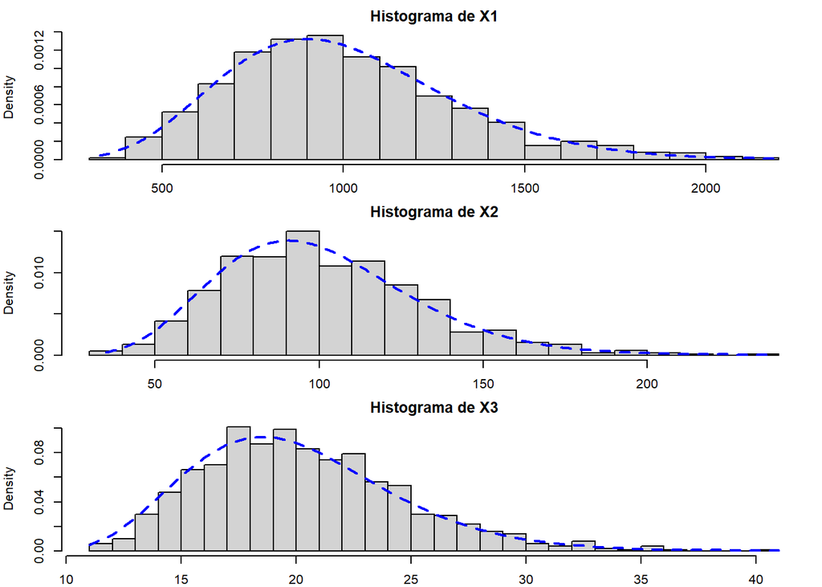

```r
U<- runif(10)

rNBinom <- function(n, r, p){
  # esse gerador simula uma binomial negativa
  # contando as x tentativas ate que se obtenham r sucessos
  Y<- numeric(n)
  for(i in 1:n){
    X <- 1
    suc <-0
    while(suc < r){
      U<- runif(1)
      if(U<=p) suc <- suc+1
      X<- X+1
    }
    Y[i] <- X
  }
  return(Y)
}

#testando a geradora
r<- 10
p<- c(0.01,0.1,0.5)
X<- sapply(p, rNBinom, n=1E3,r=r)

## B) e C)
#histogramas e funcoes probabilidade
par(mfrow=c(3,1), mar=c(2,4,2,1))
for(i in 1:3){
  hist(X[,i], freq=F,breaks=25,
       main=paste0("Histograma de X",i))
  valores<- sort(unique(X[,i]))
  lines(valores,dnbinom(valores-r,size=r,prob=p[i]),
        lwd=2,lty=2,col="blue")
}
```

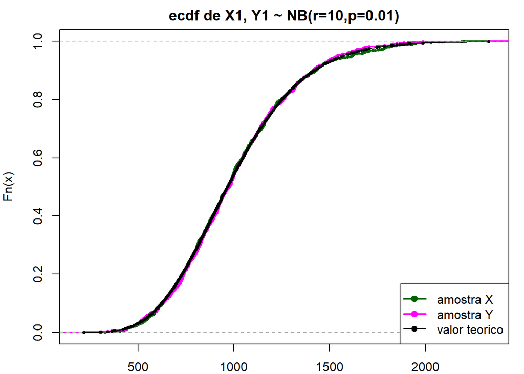

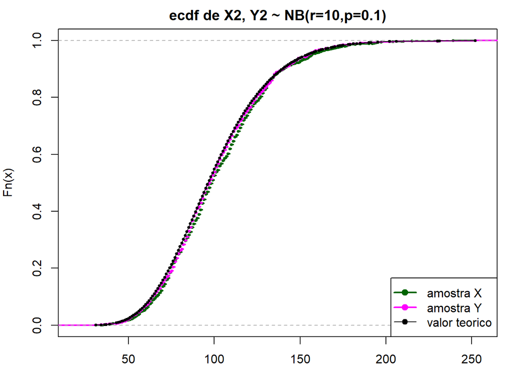

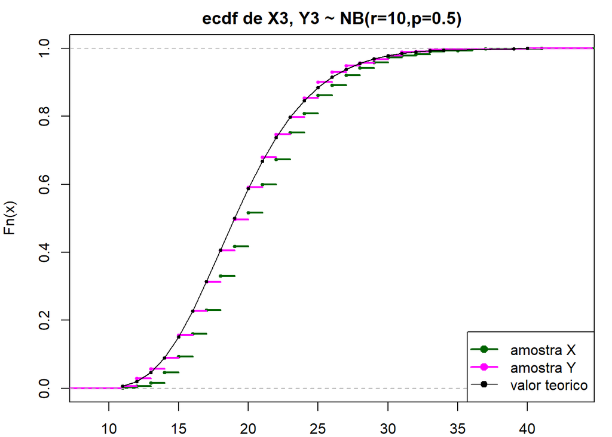

```r
## D)
# soma-se r aqui porque a parametrização dada por Ross é diferente da que o R usa
# (Ross conta todas as tentativas e rnbinom() conta somente as "falhas")
Y <- sapply(p, function(p) rnbinom(1E3, size=r, p) + r)

#comparacao de cumulativas empíricas com a real
par(mfrow=c(1,1))
for(i in 1:3){
  plot(ecdf(X[,i]),col="darkgreen",lwd=2,cex=.5,
       main=paste0("ecdf de X",i,", Y",i, " ~ NB(r=10,p=",p[i],")"))
  lines(ecdf(Y[,i]),col="magenta",lwd=2,cex=.5)
  valores<- sort(unique(Y[,i]))
  lines(valores,pnbinom(valores-r,size=r,prob=p[i]),
        lwd=1,type="o",pch=19,cex=.5)
  legend("bottomright",legend=c("amostra X","amostra Y","valor teorico"),
       col=c("darkgreen","magenta","black"),lwd=c(2,2,1),pch=19)
}
```

```r
tab<-list()
for(i in 1:3){
  tab[[i]]<- rbind(amostra=c(media=mean(X[,i]),variancia=var(X[,i])),
                   amostra.R=c(media=mean(Y[,i]),variancia=var(Y[,i])),
                   teoricos= c(r/p[i], r*(1-p[i])/p[i]^2))
}
names(tab) <- paste0("p",p)
tab
```

```
$p0.01
             media variancia
amostra   1004.114  100732.6
amostra.R 1000.465   93624.2
teoricos  1000.000   99000.0

$p0.1
            media variancia
amostra   102.255  927.0250
amostra.R 100.754  910.0535
teoricos  100.000  900.0000

$p0.5
           media variancia
amostra   20.861  19.56725
amostra.R 19.896  19.44663
teoricos  20.000  20.00000
```

As duas funções geradoras conseguem trazer resultados satisfatórios, a do R base sendo um pouco melhor.

# Questão 9

**Geração de Números Aleatórios de Misturas:**

Implementação de código em R para construir e estudar o desempenho de geradores de números aleatórios de misturas de distribuições normais e de distribuições gama. Cada discente apresentará individualmente seus resultados para as seguintes composições de misturas: discentes com matrícula de final ímpar, devem resolver as composições ímpares; discentes com matrículas de final par, os pares * .

*As misturas pares foram omitidas por não serem necessárias no desenvolvimento da questão

- **Composição de Normais # 1 e 2:**

$$\sum_{k=0}^7 \frac{1}{8}
\text{N}\left( 3\left[ \left(\frac{2}{3}\right)^k -1\right], \left(\frac{2}{3}\right)^{2k} \right)$$

- **Composição de Normais # 3:**

$$\frac{1}{2} \text N\left( -\frac{3}{2}, \left(\frac{1}{2}\right)^2 \right) +
\frac{1}{2} \text N\left( \frac{3}{2}, \left(\frac{1}{2}\right)^2 \right)$$

- **Composição de Normais # 5:**

$$\frac{1}{2} \text N(0,1) + \sum^4_{k=0} \frac{1}{10}
\text N\left( \frac{k}{2}-1, \left( \frac{1}{10} \right)^2 \right)$$

- **Composição de Gamas # 1:**

$$\frac{2}{3}\text{Gamma}\left( \alpha = 11, \lambda= \frac{1}{20} \right) +
\frac{1}{3}\text{Gamma}\left( \alpha = 11, \lambda= \frac{7}{20} \right)$$

#### Questões:

1. Para cada uma das misturas listadas acima, calcular (ou aproximar) os valores exatos (populacionais) da média, da variância, do coeficiente de assimetria e do excesso de curtose
2. Gerar n = 100 valores de cada mistura.
3. Para cada amostra gerada, estimar os valores da média, da variância, do coeficiente de assimetria e do excesso de curtose. Comparar com os valores exatos e comentar. Quando possível, conduza um teste de hipóteses e tire suas conclusões em termos de significância estatística obtida no teste.
4. Construa um histograma (DE DENSIDADE) de cada amostra e compare-o com a curva da densidade exata da mistura correspondente. Em seu gráfico, acrescente uma estimação suavizada da densidade por meio da função `density()`. Comente suas observações sobre a visualização obtida. Conduza também um teste de $\mathcalχ^2$, baseando-se na quantidade de valores observados em 10 intervalos equiprováveis no suporte obtido pela sua amostra. Com base no resultado do teste de hipóteses, conclua sobre a qualidade de seu gerador.
5. Para cada amostra, construa o gráfico da função de distribuição empírica dos valores gerados. Acrescente em sua visualização o gráfico da função de distribuição acumulada da mistura correspondente e comente. Conduza um teste de Kolmogorov-Smirnof e comente sua conclusão sobre o desempenho de seu gerador.

Primeiro irei salvar os parâmetros de cada mistura:

```r
#lista das misturas
m<-list()
## Normais
#MISTURA 1
m$mist1 <- list()
m$mist1$mi <- 3*((2/3)^(0:7)-1)
m$mist1$sig <- (2/3)^(0:7)
m$mist1$probs <- rep(1/8,8)

#MISTURA 2
m$mist2 <- list()
m$mist2$mi <- c(-1.5,1.5)
m$mist2$sig <- c(0.5,0.5)
m$mist2$probs <- c(0.5,0.5)

#MISTURA 3
m$mist3 <- list()
m$mist3$mi <- c(0, (0:4)/2-1)
m$mist3$sig <- c(1,rep(0.1,5))
m$mist3$probs <- c(0.5,rep(0.1,5))

## Gama
#MISTURA 4
m$mist4 <- list()
m$mist4$a <- c(11,11)
m$mist4$lam <- c(1/20,7/20)
m$mist4$probs <- c(2/3,1/3)
```

#### A) Cálculo dos momentos

Primeiramente devemos saber que, sejam $M$ uma mistura de $n$ V.As $X_k$ e $H(.)$ uma função para a qual $\text E[H(X_K)]$ existe, e que as densidades $f_k(x)$ existem:

$$\text E[H(M)] = \int^\infty_{-\infty}H(x)\sum^{n}_{k=1} \omega_kf_k(x)dx=\sum^{n}_{k=1}\int^\infty_{-\infty}H(x)f_k(x)dx=
\sum^{n}_{k=1}\omega_k\text E[H(X_k)]$$

onde $\omega_k$ são os pesos de cada parcela da mistura $M$ e $\sum^n_{k=1}\omega_k=1$.

```r
#funcao momento para as gamas
#(vetorizada para varios parametros lambda e alfa)
momentoGama <- function(n,lam,a){
    return(1/(lam^n)*sapply(a,function(a)prod(a+(1:n)-1)))
  }
```

#### Média ($\mu_M$)

Para as composições normais é fácil obter as médias populacionais, já que estão explícitas pelo parâmetro $\mu$:

Por exemplo, para a mistura # 1 ($M_1$):

$$\begin{aligned}
\mu_{M_1}=\text E[M_1] = \text E\left[ \frac{1}{8}\sum^8_{k=1} X_k \right] = \frac{1}{8} E\left[\sum^7_{k=1} X_k \right]=
\frac{1}{8}\sum^8_{k=1} E[X_k] = \frac{3}{8}\sum^7_{k=0} \left(\frac{2}{3}\right)^k - 1 &&
\end{aligned}$$

No caso geral, nós temos que:

$$\begin{aligned}
\text E[M_i] =\sum^{n}_{k=1} \omega_kE[X_k], &&
\end{aligned}$$

```r
#funcao calcMedia
calcMedia <- function(mist,gamma=F){
  if(gamma) return( sum( mist$probs*momentoGama(1,mist$lam,mist$a)) )
  return(sum(mist$probs*mist$mi))
}
#medias misturas
for(i in 1:4){
  print(m[[i]]$media <- calcMedia(m[[i]],i==4))
}
```

```
[1] -1.918896
[1] 0
[1] 0
[1] 157.1429
```

#### Variância ($\sigma_M^2$)

Para calcular a variância, temos:

$$\sigma_M^2=\text{Var}(M_i)= \text E[M_i^2] - \mu_{M_i}^2 = \sum^{n}_{k=1} \omega_kE[X_k^2] - \mu_{M_i}^2 =
\sum^{n}_{k=1} \omega_k(\sigma^2_{X_k}+\mu^2_{X_k}) - \mu_{M_i}^2$$

```r
#funcao calcVar
calcVar <- function(mist,gamma=F){
  if(gamma){
    medias <- mist$a/mist$lam;    vars <- mist$a/mist$lam^2
  }
  else{
    medias <- mist$mi;    vars <- mist$sig^2
  }
  return(sum(mist$probs*(vars+medias^2)) - mist$media^2)
}
#variancias misturas
for(i in 1:4){
  print(m[[i]]$var <- calcVar(m[[i]],i==4))
}
```

```
[1] 1.077788
[1] 2.5
[1] 0.755
[1] 10865.31
```

#### Assimetria $( \text{Skew}(M) )$

A assimetria é obtida pelo momento padronizado:

$$\text{Skew}(A)=\text E\left[\left( \frac{A-\mu_A}{\sigma_A} \right)^3 \right]=
\frac{\text E[A^3] - 3\mu_A\sigma_A^2-\mu_A^3}{\sigma^3_A}$$

Aplicando-o a uma mistura:

$$\text{Skew}(M) = \frac{\text E[M^3] - 3\mu_M\sigma_M^2-\mu_M^3}{\sigma^3_M}=
\frac{\sum^{n}_{k=1}\omega_k\text E[X_k^3] - 3\mu_M\sigma_M^2-\mu_M^3}{\sigma^3_M}$$

```r
#funcao calcAssim
calcAssim <- function(mist,gamma=F){
  if(gamma)
    skew <- with(mist,
                  (sum(probs*momentoGama(3,lam,a))-3*media*var-media^3)/-var^1.5)
  else
    skew <- with(mist,
                  (sum(probs*mi^3+3*mi*sig^2)-3*media*var-media^3)/-var^1.5)
  return(skew)
}
#assimetrias misturas
for(i in 1:4){
  print(m[[i]]$skew <- calcAssim(m[[i]],i==4))
}
```

```
[1] 1.186965
[1] 0
[1] 0
[1] -0.14362
```

#### Curtose $(\text{Kurt}(M))$

A curtose é dada pelo momento padronizado:

$$\text{Kurt}(A)=\text E\left[\left( \frac{A-\mu_A}{\sigma_A}\right)^4 \right]=
\frac{\text E[(A-\mu_A)^4]}{(\text E[(A-\mu_A)^2])^2}$$

E o excesso de curtose é $\text{Kurt}(A) - 3$. Uma outra forma comum de calcular a curtose de uma mistura $M$ é fazendo uma média ponderada das curtoses de seus fatores $X_k$ de acordo com seus pesos $\omega_k$. Além disso, temos que o excesso de curtose de V.A’s Gama($\alpha,\lambda$) é igual a $6/\alpha$ e de V.A’s normais é igual a 0.

Tomando isso em conta, temos:

```r
#excesso de curtose misturas
for(i in 1:3){
  print(m[[i]]$kurt <- with(m[[i]], sum(probs*3) - 3))
}
```

```
[1] 0
[1] 0
[1] 0
```

```r
(m[[4]]$kurt <- with(m[[4]], sum(probs*(6/a +3)) - 3))
```

```
[1] 0.5454545
```

#### B) Geração de amostras das misturas

```r
## NORMAIS

#funcao geradora de normais
rNorm<- function(n,mu=0,sd=1){
  # usa Box-Muller (mas só retorna Z1*sigma+mi)
  U1<- runif(n)
  U2<- runif(n)
  a<- sqrt(-2*log(U1))
  b<- 2*pi*U2
  return(a*cos(b)*sd+mu)
}

## GAMA
#podemos fazer essa estimativa por meio de soma de a exponenciais(lambda), de forma:
rGama <- function(n, a, lam){
  #eu usaria a propriedade da soma de logs, mas ele estava sendo
  #arredondado para 0 e isso levava a um erro de computaçao
  return( apply(replicate(n,runif(a)),2, function(u) sum(-log(u))/lam) )
}


#funcao geradora de mistura
rMisturaNormGama <- function(n,mist,gamma=F){
  par1 <- mist[[1]]
  par2 <- mist[[2]]
  probs <- mist$probs
  k<- length(par2)
  X<- numeric(n)
  U <- runif(n)
  p <- cumsum(c(0,probs))
  #CASO GAMA
  if(gamma){
    for(i in 1:k){
      caso <- U <= p[i+1] & U> p[i]
      tam <- sum(caso)
      X[caso] <- rGama(tam,par1[i],par2[i])
    }
    return(X)
  }
  #CASO NORMAL
  for(i in 1:k){
    caso <- U <= p[i+1] & U> p[i]
    tam <- sum(caso)
    X[caso] <- rNorm(tam,par1[i],par2[i])
  }
  return(X)
}

n<-100
#inicializando a matriz das amostras
amostra <- mapply(rMisturaNormGama,n=n,mist=m,gamma=c(F,F,F,T))
colnames(amostra) <- c(paste0("Norm",c(1,2,3)),"Gamas")
```

#### C) Momentos amostrais

```r
## MEDIA AMOSTRAL
medias <- apply(amostra,2,mean)
#teste de hipótese
for(i in 1:4){
  print(t.test(amostra[,i],mu=m[[i]]$media))
}
```

```
    One Sample t-test

data:  amostra[, i]
t = -0.58513, df = 99, p-value = 0.5598
alternative hypothesis: true mean is not equal to -1.918896
95 percent confidence interval:
 -2.172683 -1.780701
sample estimates:
mean of x
-1.976692


    One Sample t-test

data:  amostra[, i]
t = -1.6544, df = 99, p-value = 0.1012
alternative hypothesis: true mean is not equal to 0
95 percent confidence interval:
 -0.5667914  0.0513792
sample estimates:
 mean of x
-0.2577061


    One Sample t-test

data:  amostra[, i]
t = -0.53337, df = 99, p-value = 0.595
alternative hypothesis: true mean is not equal to 0
95 percent confidence interval:
 -0.2167240  0.1248945
sample estimates:
  mean of x
-0.04591475


    One Sample t-test

data:  amostra[, i]
t = -0.43668, df = 99, p-value = 0.6633
alternative hypothesis: true mean is not equal to 157.1429
95 percent confidence interval:
 130.9022 173.9169
sample estimates:
mean of x
 152.4096
```

```r
## VARIANCIA AMOSTRAL
vars <- apply(amostra,2,var)
#teste de hipótese
suppressPackageStartupMessages(library(EnvStats,quietly=T))
for(i in 1:4){
  print(varTest(amostra[,i],sigma.squared = m[[i]]$var))
}
```

```
Results of Hypothesis Test
--------------------------

Null Hypothesis:                 variance = 1.077788

Alternative Hypothesis:          True variance is not equal to 1.07778810805067

Test Name:                       Chi-Squared Test on Variance

Estimated Parameter(s):          variance = 0.9756539

Data:                            amostra[, i]

Test Statistic:                  Chi-Squared = 89.61848

Test Statistic Parameter:        df = 99

P-value:                         0.5213689

95% Confidence Interval:         LCL = 0.7521277
                                 UCL = 1.3166346


Results of Hypothesis Test
--------------------------

Null Hypothesis:                 variance = 2.5

Alternative Hypothesis:          True variance is not equal to 2.5

Test Name:                       Chi-Squared Test on Variance

Estimated Parameter(s):          variance = 2.426489

Data:                            amostra[, i]

Test Statistic:                  Chi-Squared = 96.08897

Test Statistic Parameter:        df = 99

```

[output cut: 35 more lines]

```

Test Name:                       Chi-Squared Test on Variance

Estimated Parameter(s):          variance = 11748.83

Data:                            amostra[, i]

Test Statistic:                  Chi-Squared = 107.0503

Test Statistic Parameter:        df = 99

P-value:                         0.5455849

95% Confidence Interval:         LCL =  9057.13
                                 UCL = 15854.93
```

```r
## ASSIMETRIA AMOSTRAL
assimet <- apply(amostra,2,skewness)

## CURTOSE AMOSTRAL
curtose <- apply(amostra,2,kurtosis)



#comparacao em tabela
rbind(mi.amostra=medias, mi.teorico=sapply(m,function(ms) ms$media))
```

```
               Norm1      Norm2       Norm3    Gamas
mi.amostra -1.976692 -0.2577061 -0.04591475 152.4096
mi.teorico -1.918896  0.0000000  0.00000000 157.1429
```

```r
rbind(var.amostra=vars,var.teorico=sapply(m,function(ms) ms$var))
```

```
                Norm1    Norm2     Norm3    Gamas
var.amostra 0.9756539 2.426489 0.7410449 11748.83
var.teorico 1.0777881 2.500000 0.7550000 10865.31
```

```r
rbind(skew.amostra=assimet, skew.teorico=sapply(m,function(ms) ms$skew))
```

```
                Norm1   Norm2      Norm3      Gamas
skew.amostra 1.379674 0.14454 -0.4633456  0.2076593
skew.teorico 1.186965 0.00000  0.0000000 -0.1436200
```

```r
rbind(kurt.amostra=curtose, kurt.teorico=sapply(m,function(ms) ms$kurt))
```

```
               Norm1     Norm2    Norm3      Gamas
kurt.amostra 1.21187 -1.633572 1.020008 -1.2054190
kurt.teorico 0.00000  0.000000 0.000000  0.5454545
```

No geral, as amostras tiveram média e variâncias consistentes com seus valores teóricos. A curtose não se parece muito com o valor calculado, provavelmente porque não usei a definição, mas sim uma média ponderada.

#### D) Histograma das amostras

```r
##FUNCOES DE DISTRIBUIÇÃO ACUMULADA##
pMisturaNorm <- function(x,mi,dp,probs){
  n <- length(mi)
  if(length(x)==1)
    return(sum(probs*pnorm(x,mi,dp)))
  #
  return(rowSums(sapply(1:n,function(k) probs[k]*pnorm(x,mi[k],dp[k]))))
} #misturas normais

pMisturaGama <- function(x,a,lam,probs){
  n <- length(a)
  if(length(x)==1)
    return(sum(probs*pgamma(x,a,rate=lam)))
  #
  return(rowSums(sapply(1:n,function(k) probs[k]*pgamma(x,a[k],rate=lam[k]))))
} #misturas gama

##FUNCOES DENSIDADE DE PROBABILIDADE##

dMisturaNorm <- function(x,mi,dp,probs){
  n <- length(mi)
  if(length(x)==1)
    return(sum(probs*dnorm(x,mi,dp)))
  #
  return(rowSums(sapply(1:n,function(k) probs[k]*dnorm(x,mi[k],dp[k]))))
} #normais

dMisturaGama <- function(x,a,lam,probs){
  n <- length(a)
  if(length(x)==1)
    return(sum(probs*dnorm(x,a,rate=lam)))
  #
  return(rowSums(sapply(1:n,function(k) probs[k]*dgamma(x,a[k],rate=lam[k]))))
} #misturas gama

##FUNCAO QUANTILICA (POR APROXIMACAO)##

qMistura <- function(p,mist,limite=c(-1E4,1E4),gamma=F)
{
  if(gamma)
    equacao <- function(x)
      return(pMisturaGama(x,mist$a,mist$lam,mist$probs) - p)
  else
    equacao <- function(x)
      return(pMisturaNorm(x,mist$mi,mist$sig,mist$probs) - p)
  return( uniroot(equacao,limite)$root )
}
```

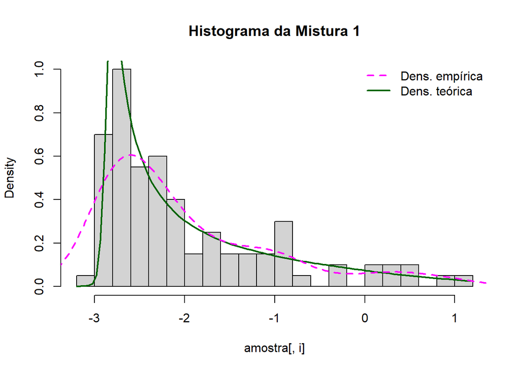

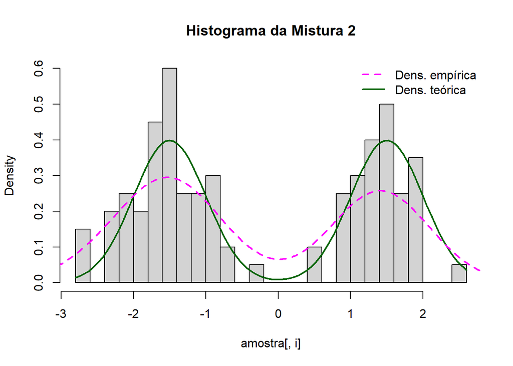

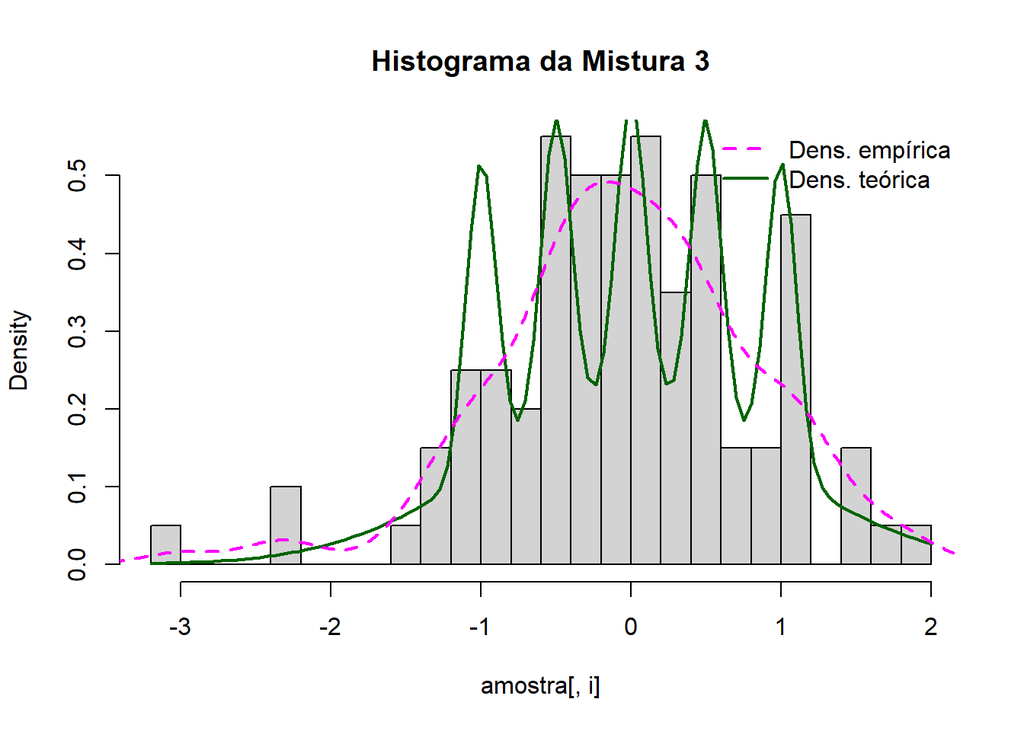

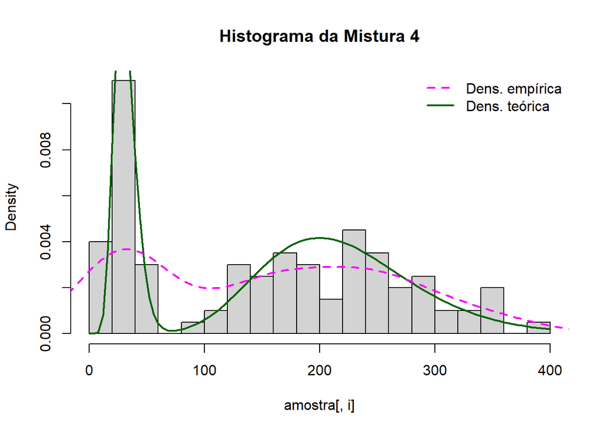

```r
for(i in 1:4){
  hist(amostra[,i],freq=F,breaks=25,main=paste("Histograma da Mistura", i))
  op<- par(no.readonly = T)
  par(lwd=2,col="darkgreen")
  if(i==4)
    with(m[[4]],
         curve(dMisturaGama(x,a,lam,probs),
                               add=T))
  else
    with(m[[i]],
         curve(dMisturaNorm(x,mi,sig,probs),
                               add=T))
  lines(density(amostra[,i]),col="magenta",lty=2)
  par(op)
  legend("topright",legend=c("Dens. empírica","Dens. teórica"),
       col=c("magenta","darkgreen"),lwd=2,lty=2:1,bty="n")
}
```

```r
rm(op)
```

As amostras parecem bem ajustadas às densidades teóricas.

Teste Qui-Quadrado:

$$\begin{aligned}
& H_o: \text{A amostra está distribuida uniformemente nas caselas}
\\
& H_a: \text{Caso contrário}
\end{aligned}$$

```r
partes <- matrix(ncol=4,nrow=100)
for(i in 1:4){
  quantis <- sapply((0:10)/10, function(p) qMistura(p, m[[i]],gamma= i==4))
  partes[,i]<- cut(amostra[,i],quantis)
}

tabela <- apply(partes,2,table)

apply(tabela,2,chisq.test)
```

```
[[1]]

    Chi-squared test for given probabilities

data:  newX[, i]
X-squared = 1.4, df = 9, p-value = 0.9978


[[2]]

    Chi-squared test for given probabilities

data:  newX[, i]
X-squared = 8.4, df = 9, p-value = 0.4944


[[3]]

    Chi-squared test for given probabilities

data:  newX[, i]
X-squared = 5.4, df = 9, p-value = 0.7981


[[4]]

    Chi-squared test for given probabilities

data:  newX[, i]
X-squared = 7.6, df = 9, p-value = 0.5749
```

Os testes Qui-Quadrado resultaram em p-valores insuficientes para rejeitar a hipótese nula.

#### E) Gráficos da acumulada empírica

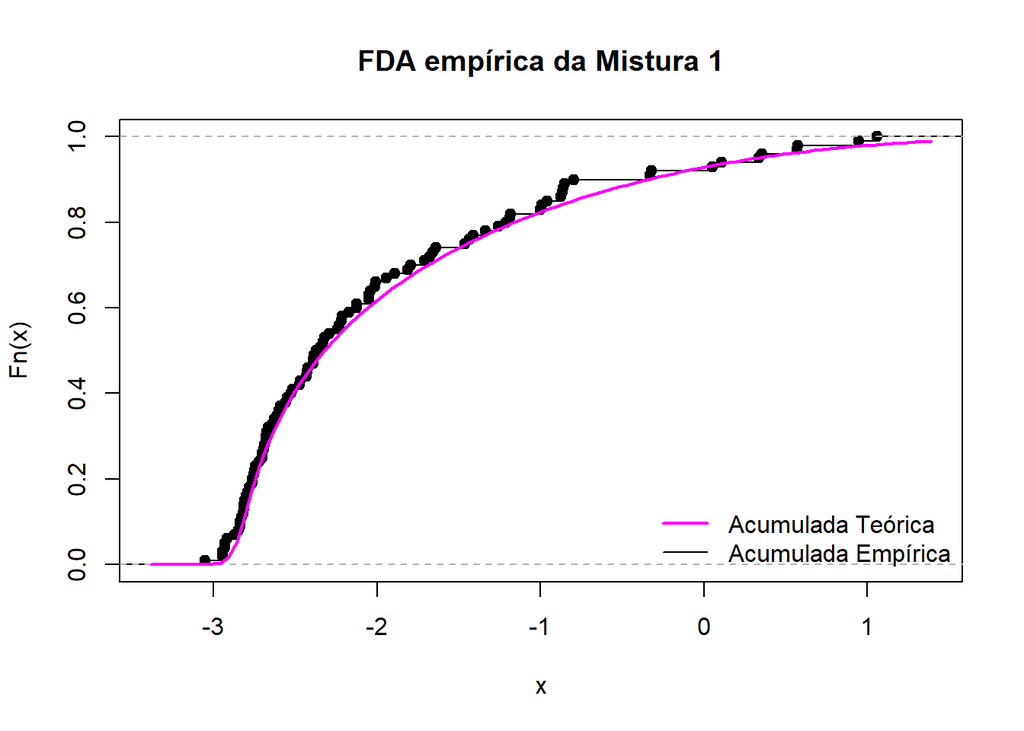

```
Results of Hypothesis Test
--------------------------

Alternative Hypothesis:          two-sided

Test Name:                       Asymptotic one-sample Kolmogorov-Smirnov test

Data:                            amostra[, i]

Test Statistic:                  D = 0.04881419

P-value:                         0.9710268
```

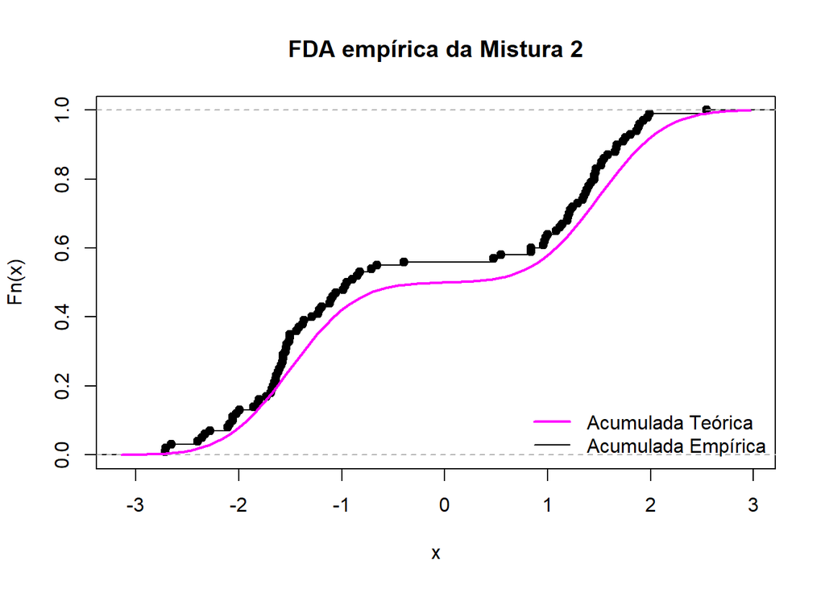

```
Results of Hypothesis Test
--------------------------

Alternative Hypothesis:          two-sided

Test Name:                       Asymptotic one-sample Kolmogorov-Smirnov test

Data:                            amostra[, i]

Test Statistic:                  D = 0.101443

P-value:                         0.254852
```

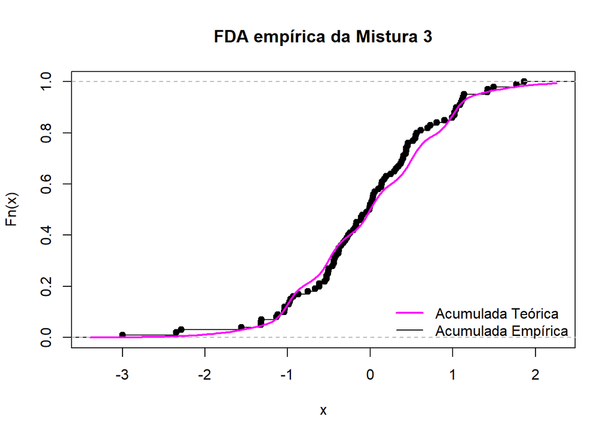

```
Results of Hypothesis Test
--------------------------

Alternative Hypothesis:          two-sided

Test Name:                       Asymptotic one-sample Kolmogorov-Smirnov test

Data:                            amostra[, i]

Test Statistic:                  D = 0.0871687

P-value:                         0.4329867
```

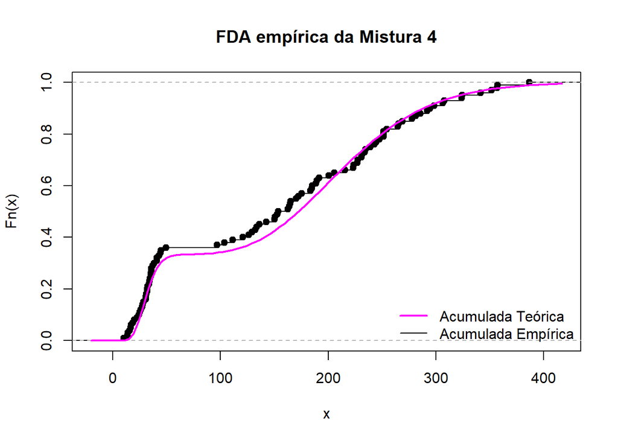

```
Results of Hypothesis Test
--------------------------

Alternative Hypothesis:          two-sided

Test Name:                       Asymptotic one-sample Kolmogorov-Smirnov test

Data:                            amostra[, i]

Test Statistic:                  D = 0.06670864

P-value:                         0.7650917
```

```r
for(i in 1:4){
  plot(ecdf(amostra[,i]),main=paste("FDA empírica da Mistura", i))
  op<- par(no.readonly = T)
  par(lwd=2,col="magenta")
  if(i==4){
    #curva da acumulada teorica
    with(m[[4]],
         curve(pMisturaGama(x,a,lam,probs),
                               add=T))
    #teste K-S
    with(m[[i]],
         print(ks.test(amostra[,i],pMisturaGama,a=a,lam=lam,probs=probs)) )
  }
  else{
    #curva da acumulada teorica
    with(m[[i]],
         curve(pMisturaNorm(x,mi,sig,probs),
                               add=T))
    #teste K-S
    with(m[[i]],
         print(ks.test(amostra[,i],pMisturaNorm,mi=mi,dp=sig,probs=probs)) )
  }
  par(op)
  legend("bottomright",legend=c("Acumulada Teórica","Acumulada Empírica"),
       col=c("magenta","black"),lwd=2:1,bty="n")
}
```

Visualmente e pelos testes K-S, podemos dizer que as amostras geradas são suficientemente boas. Para $\alpha=0.05$, os p-valores são suficientes para não rejeitar a hipótese nula. Além disso, os gráficos das FDA’s empíricas são decentemente ajustados às teóricas. Se fosse desejado conseguir uma amostra ainda mais próxima à distribuição das misturas, basta aumentar o valor de `n`.

# Questões Pares

Algumas questões que eu não precisava fazer, mas fiz mesmo assim (porque eu esqueci que era só para fazer as ímpares).

## Questão 2

**Enunciado:** Apresente um código que gere os valores de X, onde:

$$f_X(j)=P(X=j)= \left( \frac{1}{2} \right)^{j+1}
+\frac{\left( \frac{1}{2} \right)2^{j-1}}{3^j},\quad j=1,2,...$$

Podemos observar que essa função de probabilidade é a mistura de duas geométricas: $G_1 \sim \text{Geom}(1/2)$ e $G_2 \sim \text{Geom}(1/3)$ ambas com $\alpha = 0.5$.

```r
# 1- Funcao geradora de Geometricas
rGeom <- function(n,p){
  U <- runif(n)
  G <- log(U) %/% log(1-p) + 1
  return(G)
}
# 2- Funcao geradora de X
rMist <- function(n){
  U <- runif(n)
  X<- numeric(n)
  caso1 <- U <= 0.5
  #
  X[caso1] <- rGeom( sum(caso1), 1/2 )
  X[!caso1] <- rGeom( sum(!caso1), 1/3 )
  return(X)
}

X <- rMist(1E3)

#MONTANDO UMA TABELA PARA COMPARAR AS PROPORCOES GERADAS COM AS PROPORCOES TEORICAS
tab.empirica <- table(X)/1E3
valores <- sort(unique(X))
tab.teorica <- dgeom(valores-1,1/2)*0.5 + dgeom(valores-1,1/3)*0.5

rbind("Prop. Amostral"= tab.empirica,"Prop. Teorica"= tab.teorica)
```

```
                       1         2         3          4          5          6
Prop. Amostral 0.4180000 0.2380000 0.1150000 0.09200000 0.05100000 0.03400000
Prop. Teorica  0.4166667 0.2361111 0.1365741 0.08063272 0.04854681 0.02976037
                        7          8           9          10          11
Prop. Amostral 0.01700000 0.01100000 0.008000000 0.008000000 0.005000000
Prop. Teorica  0.01853817 0.01170774 0.007479636 0.004823664 0.003134396
                        12           14           18
Prop. Amostral 0.001000000 0.0010000000 0.0010000000
Prop. Teorica  0.002048907 0.0008868894 0.0001710672
```

## Questão 4

**Enunciado:** Seja $S_N= \displaystyle\sum^N_{i=1} e^{i/N}$, em que $N=10.000$.

1. Explique como você poderia encontrar uma aproximação para $S_N$, usando 100 números aleatórios.
2. Obtenha a aproximação de $S_N$.
3. A aproximação obtida em (b) é boa?

Podemos aproximar o valor de $S_N$ por meio de uma média $\mu=\frac{S_N}{N}$, a qual pode ser estimada por uma média amostral.

#### Implementação

```r
N<- 1E4
exata <- sum(exp((1:1E4)/N))

U <- trunc(runif(100,1,N))
estimativa <- mean(exp(U/N))*1E4

cbind(exata,estimativa)
```

```
        exata estimativa
[1,] 17183.68   17114.94
```

Temos uma estimativa decente, mas que pode ser melhorada (aumentando o tamanho da amostra).

## Questão 6

**Enunciado:** A variável aleatória $X$ tem função de probabilidade $p_j=\text P(X=j)$, $\displaystyle\sum^\infty_{j=1}p_j=1$. Seja:

$$\lambda_n = \text P\{ X=n | X>n-1 \} = \frac{p_n}{1-\sum^{n-1}_{j=1}p_j}, \quad j=1,2,...$$

1. Mostre que $p_1=\lambda_1$ e $p_n=(1-\lambda_1)(1-\lambda_2)...(1- \lambda_{n-1}) \lambda_n$ . As grandezas $\lambda_n$, $n \geq 1$, são denominadas taxas de risco discretas, uma vez que se pensarmos em $X$ como o tempo de vida de algum item, então $\lambda_n$ representa a probabilidade de que um item que atingiu a idade $n$ morrerá nesse período de tempo. A abordagem de simulação variáveis aleatórias discretas a seguir é denominada método da taxa de risco discreta. Ela gera uma sucessão de números aleatórios, parando quando o número aleatório $n$ é menor que $\lambda_n$. O algoritmo pode ser escrito da seguinte forma:
- PASSO 1: $X = 1$.
- PASSO 2: Gere um número aleatório $U$.
- PASSO 3: Se $U < \lambda_X$, pare.
- PASSO 4: $X = X + 1$.
- PASSO 5: Retorne ao PASSO 2.
2. Mostre que o valor de $X$ obtido com o algoritmo acima tem a função de probabilidades desejada.
3. Suponha que $X$ é uma variável aleatória geométrica com o parâmetro $p$. Determine os valores $\lambda_n$, $n \geq 1$. Explique o que o algoritmo acima está fazendo neste caso e porque sua validade está clara.

#### A) Recursividade de $\lambda_j$

Temos que:

$$\begin{align}
& \lambda_1=\frac{p_1}{1-0}=p_1 &&
\\
& \lambda_2= \frac{p_2}{1-p_1} = \frac{p_2}{1-\lambda_1} \Rightarrow
p_2=\lambda_2(1-\lambda_1)
\\
& \lambda_3= \frac{p_3}{1-p_2-p_1} = \frac{p_3}{1-\lambda_1-\lambda_2(1-\lambda_1)}
= \frac{p_3}{(1-\lambda_1)(1-\lambda_2)} \Rightarrow p_3=\lambda_3(1-\lambda_2)(1-\lambda_1)
\end{align}$$

Assim, é fácil ver que $p_n=(1-\lambda_1)(1-\lambda_2)...(1- \lambda_{n-1}) \lambda_n$.

```r
## Algoritmo do método da taxa de risco discreta

risco <- function(p){
  X <- 1
  U <- runif(1)
  lam <- p[1]
  acum <- cumsum(p)
  while(U >= lam & X< length(p)){
    X <- X + 1
    lam <- p[X]/(1-acum[X-1])
    U <- runif(1)
  }
  return(X)
}

## B)
#usaremos de exemplo a distribuicao do exercicio anterior
X<-replicate(1E3,risco(probs))
rbind(p.Gerados=table(X)/1E3,p.Teoricos= probs)
```

```
               1     2     3     4     5     6     7     8     9    10
p.Gerados  0.075 0.062 0.057 0.059 0.063 0.156 0.117 0.147 0.131 0.133
p.Teoricos 0.060 0.060 0.060 0.060 0.060 0.150 0.130 0.140 0.150 0.130
```

É visível que a amostra gerada tem proporções próximas ao parâmetro dado (probs).

#### C) $\lambda_x$ quando $X\sim\text{Geom}(p)$

$$\begin{aligned}
& \lambda_1 = p &&
\\
& \lambda_2 = \frac{(1-p)p}{1-p} = p
\\
& \lambda_3 = \frac{(1-p)^2p}{(1-p)-(1-p)p} = \frac{(1-p)p}{1-p}= p
\\
& \vdots
\\
& \lambda_n = \frac{p(1-p)^{n-1}}{1- p \sum^{n-1}_{j=1} (1-p)^{j-1}} = p
\end{aligned}$$

É fácil ver que a distribuição geométrica possui falta de memória, ou seja, a condicional $\lambda_n= \text P\{ X=n | X>n-1 \} = \text P(X=1) = p$ não depende de $n$.

Como $\lambda_n$ é constante, o algoritmo sorteia $U$ e soma 1 ao valor de $X$ até que $U < p$, ou seja, conta o número de tentativas onde o experimento “falha” e termina quando haja um sucesso.